# Trabajo Métodos Estadísticos Avanzados

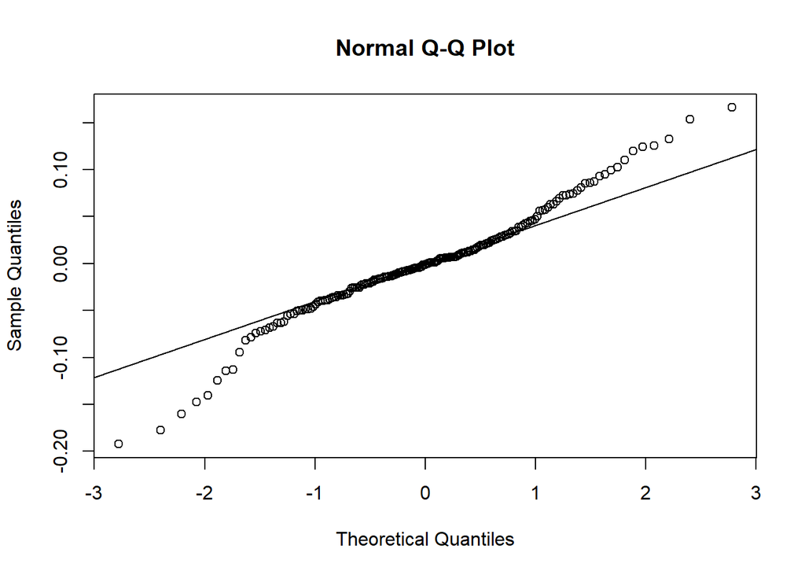

```r
qqnorm(resid(mixtos2))
qqline(resid(mixtos2))
```

```r
predichos_train = predict(mixtos2)
```

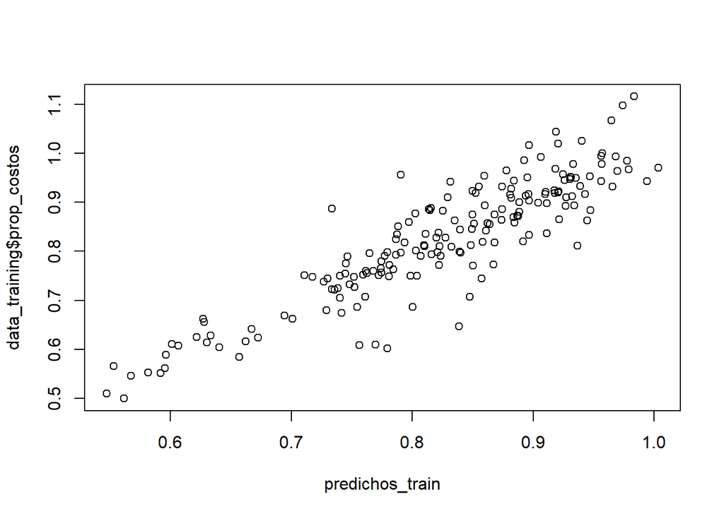

```r
plot(predichos_train, data_training$prop_costos)
```

Vemos un menor ajuste para este modelo de la proporción de los costos. Sin embargo, sigue mostrando mejores resultados que los efectos del modelo lineal múltiple mostrado con anterioridad.

```r
predichos_validation = predict(mixtos2,newdata = data_validation, allow.new.levels = TRUE)
```

```r
residuales = na.omit(data_validation$prop_costos)-predichos_validation
```

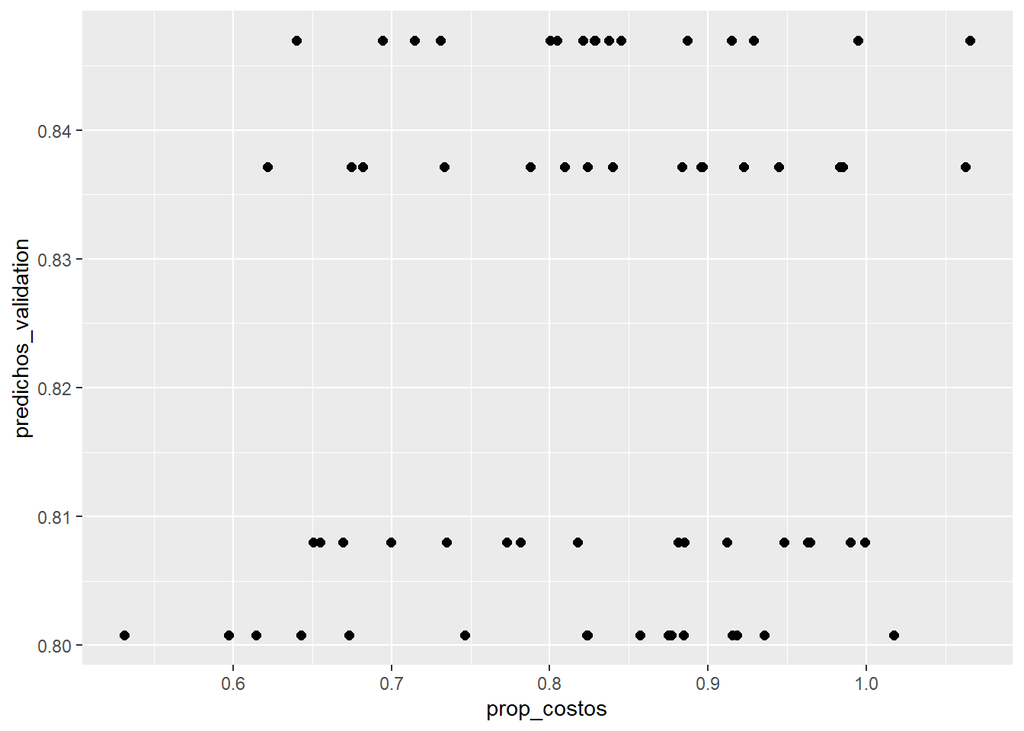

```r
ggplot(data_validation,aes(x=prop_costos,y=predichos_validation))+geom_point(size=2)
```

#### Variación Costos

```r
mixtos1 = lmer(var_costos ~ crec_pib + log_trm +(1|nit),data = data_training)
```

```
## boundary (singular) fit: see ?isSingular
```

```r
summary(mixtos1)
```

```
## Linear mixed model fit by REML ['lmerMod']
## Formula: var_costos ~ crec_pib + log_trm + (1 | nit)
##    Data: data_training
##
## REML criterion at convergence: -56.9
##
## Scaled residuals:
##     Min      1Q  Median      3Q     Max
## -8.3581 -0.3976  0.0274  0.3534  3.4285
##
## Random effects:
##  Groups   Name        Variance Std.Dev.
##  nit      (Intercept) 0.00000  0.0000
##  Residual             0.03708  0.1925
## Number of obs: 138, groups:  nit, 46
##
## Fixed effects:
##              Estimate Std. Error t value
## (Intercept) -17.70576    8.63779  -2.050
## crec_pib     -0.08564    0.03695  -2.318
## log_trm       2.24358    1.08145   2.075
##
## Correlation of Fixed Effects:
##          (Intr) crc_pb
## crec_pib  0.210
## log_trm  -1.000 -0.218
## convergence code: 0
## boundary (singular) fit: see ?isSingular
```

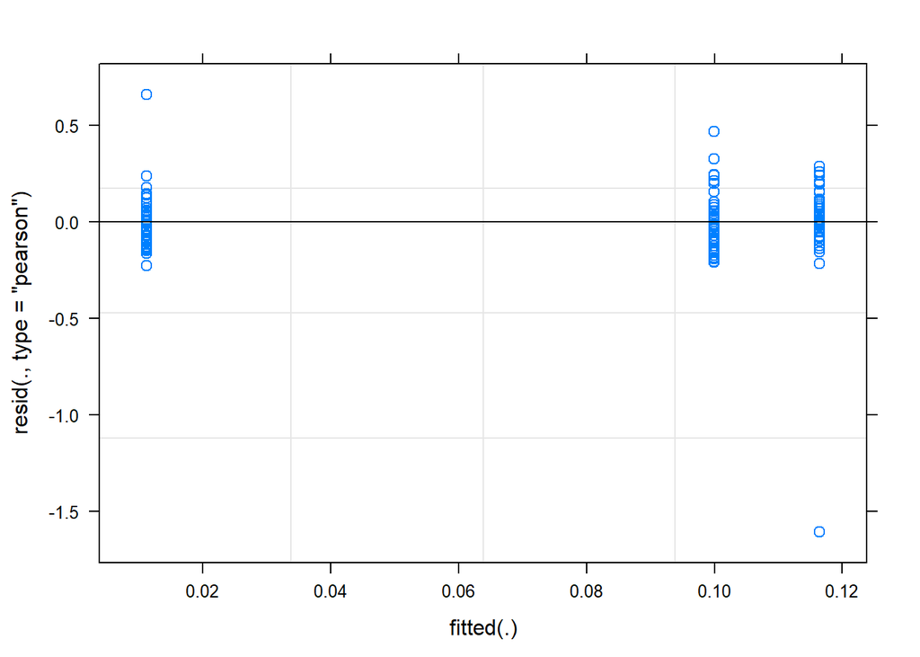

```r
plot(mixtos1)
```

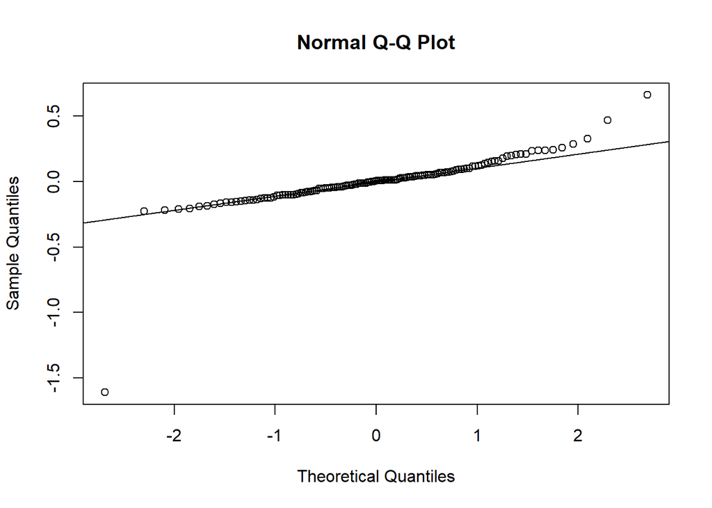

```r
qqnorm(resid(mixtos1))
qqline(resid(mixtos1))
```

```r
mixtos2 = lmer(var_costos ~ crec_pib + log_trm +(1+crec_pib|nit),data = data_training)
```

```
## boundary (singular) fit: see ?isSingular
```

```r
summary(mixtos2)
```

```
## Linear mixed model fit by REML ['lmerMod']
## Formula: var_costos ~ crec_pib + log_trm + (1 + crec_pib | nit)
##    Data: data_training
##
## REML criterion at convergence: -56.9
##
## Scaled residuals:
##     Min      1Q  Median      3Q     Max
## -8.3581 -0.3976  0.0274  0.3534  3.4285
##
## Random effects:
##  Groups   Name        Variance  Std.Dev.  Corr
##  nit      (Intercept) 5.696e-10 2.387e-05
##           crec_pib    2.534e-10 1.592e-05 -1.00
##  Residual             3.708e-02 1.925e-01
## Number of obs: 138, groups:  nit, 46
##
## Fixed effects:
##              Estimate Std. Error t value
## (Intercept) -17.70576    8.63779  -2.050
## crec_pib     -0.08564    0.03695  -2.318
## log_trm       2.24358    1.08145   2.075
##
## Correlation of Fixed Effects:
##          (Intr) crc_pb
## crec_pib  0.210
## log_trm  -1.000 -0.218
## convergence code: 0
## boundary (singular) fit: see ?isSingular
```

Los efectos fijos muestran una similitud a lo que ncontramos en el modelo de regresión lineal múltiple. Lo curioso en este caso, es que los efectos aleatorios tienen poco impacto en el modelo, es una variabilidad mínima. Esto lo refleja la gráfica de los residuales. Si vemos con atención, muestran un comportamiento similar, aunque no igual, a las estimaciones del modelo de regresión lineal múltiple, esto debido al bajo impacto de los efectos aleatorios.

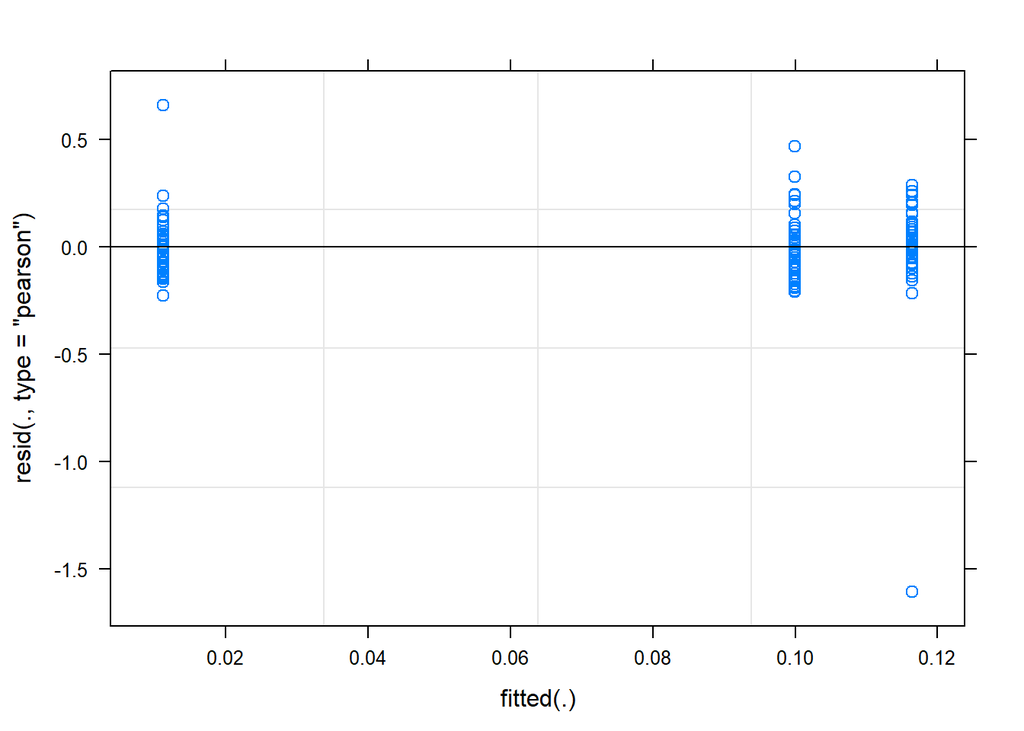

```r
plot(mixtos2)
```

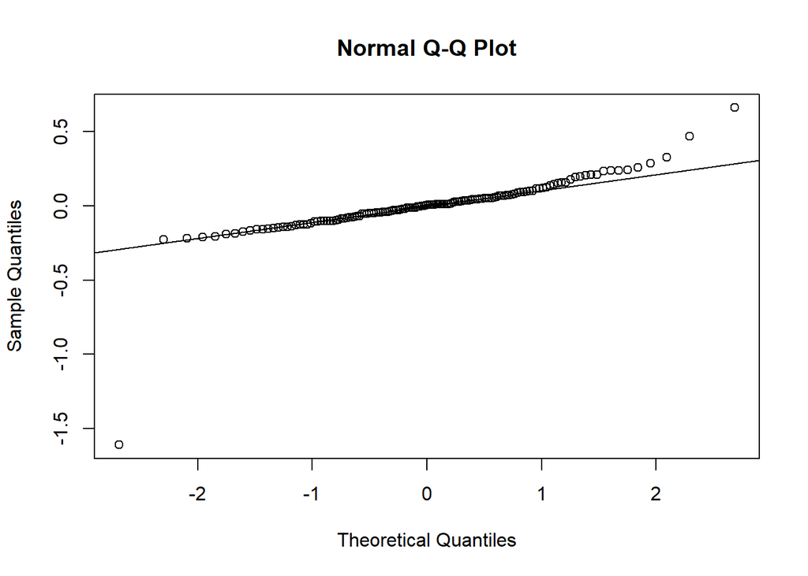

```r
qqnorm(resid(mixtos2))
qqline(resid(mixtos2))
```

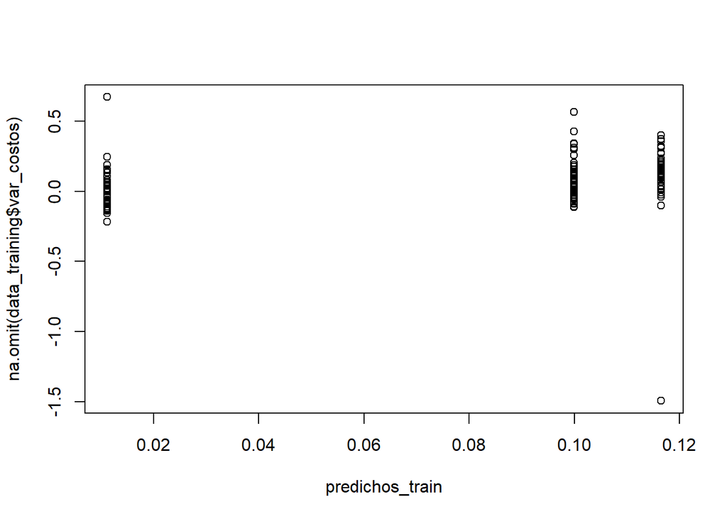

```r
predichos_train = predict(mixtos1, newdata = na.omit(data_training))
plot(predichos_train,na.omit(data_training$var_costos))
```

Vemos entonces que hay un poco más de variabilidad en las predicciones, sin embargo, el modelo de fectos mixtos para la variable de variación costos, sigue sin ajustarse bien.

# Conclusiones

Este trabajo ayuda a entender como las variables macroeconómicas impactan los costos de una empresa, en tiempos donde una pandemia mundial tien en riesgo la economía, se hace necesario concer los posibles impactos que se puedan tener. Se pudo evidenciar que los modelos de efectos mixtos son una herramienta muy útil para tener en cuenta la heterogeneidad de cada uno de los individuos, en este caso las empresas, lo que nos lleva a entender que los modelos de regresión lineal múltiple quedan cortos en algunos casos, precisamente cuando hay un comportamiento en los individuos que no se puede reflejar. El espectro de tiempo del trabajo es corto, por lo tanto el análisis es limitado para solo unas variables macroeconómicas que se pueden incluir en el modelo, de acuerdo a esto, sería interesante observar como los datos trimestrales se ajustarían con este tipo de metodologías.